# Final_Exam

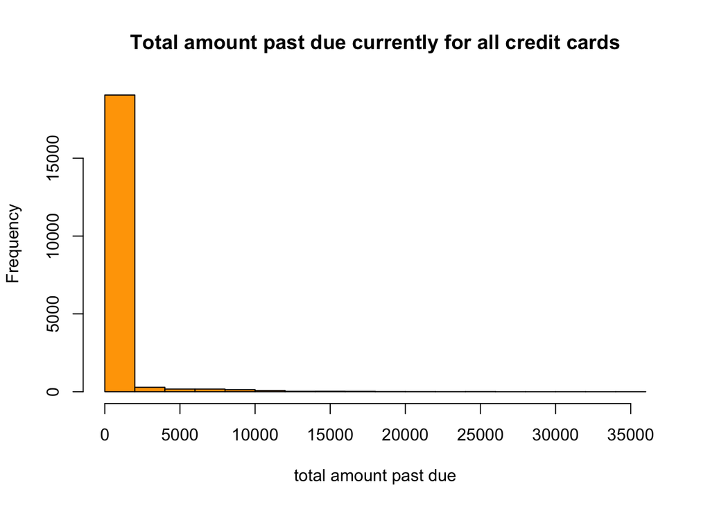

```r
hist(loan_data$tot_amount_currently_past_due, main="Total amount past due currently for all credit cards", xlab="total amount past due", ylab="Frequency", col="orange", border="black")
```

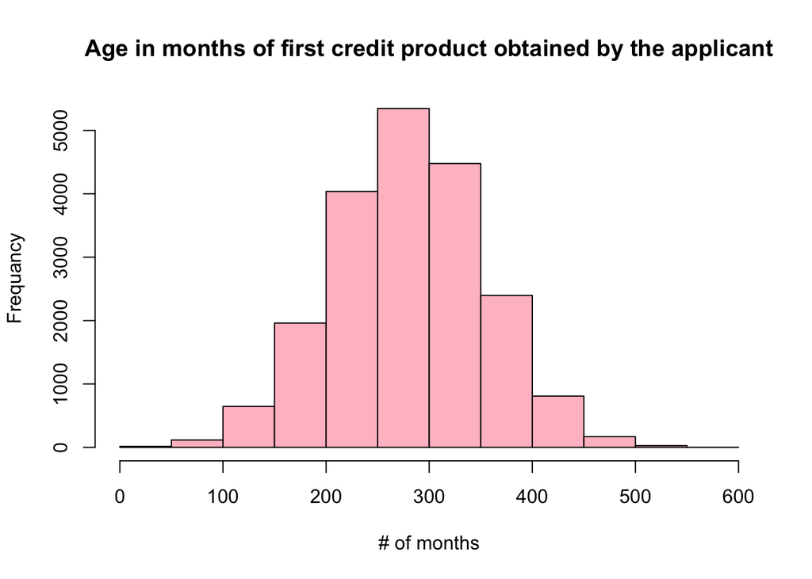

```r
hist(loan_data$credit_age, main="Age in months of first credit product obtained by the applicant", xlab="# of months", ylab="Frequancy", col="pink", border="black")
```

```r
#Yes these confirm the skewness that I found in part b.
```

4. How would your convert the “rep_education” column into numerical data? Name two ways.

```r
#1) You could assign a unique numerical label to each category in the column. The factor "function"  can be used to do this, as well as "as.numeric". This creates a new column and  assigns a numerical label to each unique category in the "rep_education" column.
#2) You could create binary columns for each category which represents the presence or absence of a category with a 1 or 0. The model.matrix function can be used for this. This called encoding.
```

Question #3 (a) Plot a bar graph for the “Def_Ind” column and describe it.

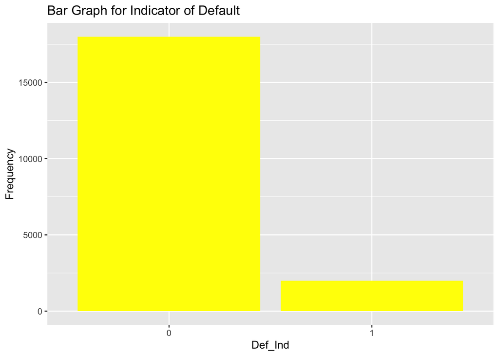

```r
library(ggplot2)

def_ind_col <- loan_data$Def_ind

ggplot(loan_data, aes(x = factor(def_ind_col))) + geom_bar(fill = "yellow") + labs(title = "Bar Graph for Indicator of Default", x="Def_Ind", y="Frequency")
```

```r
#right skewed
#mode 0 mean 0.1, median 0
```

2. Plot a bar graph for the “rep_education” column and describe it.

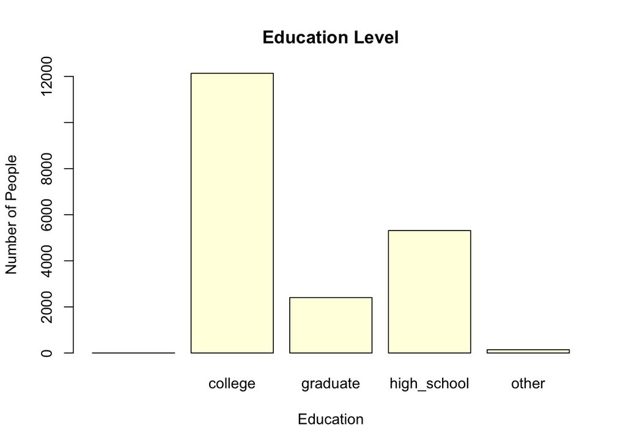

```r
barplot(table(loan_data$rep_education), main="Education Level", xlab="Education", ylab="Number of People", col="lightyellow")
```

```r
#There is a large amount of people with college level education and the next highest is high school. There is a small number of people with graduate level education and a very small amount with "other"
#Rigth skewed
```

3. Plot a histogram of the “rep_income” variable.

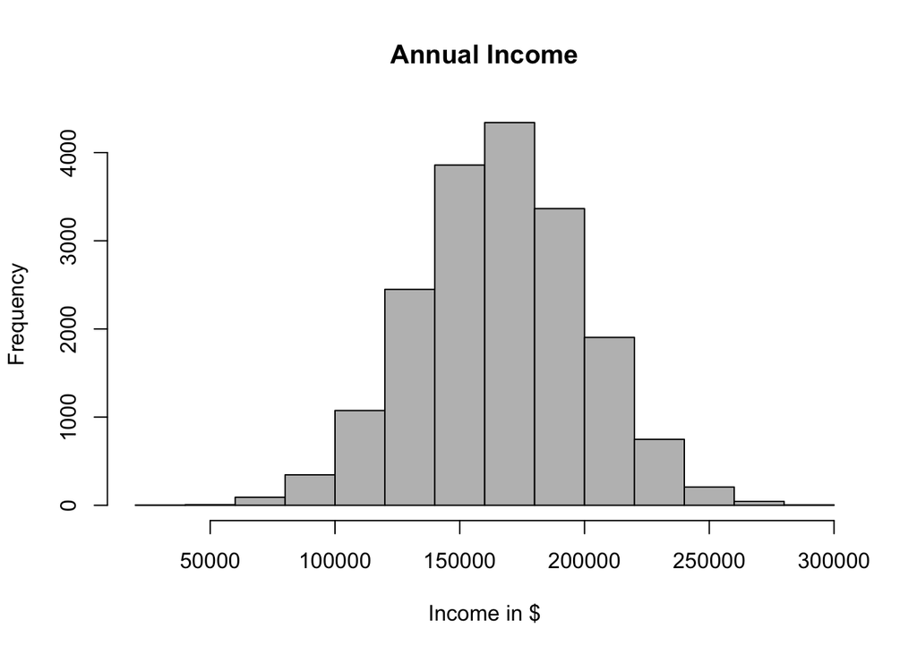

```r
hist(loan_data$rep_income, main="Annual Income", xlab="Income in $", ylab="Frequency", col="grey", border="black")
```

(d) Plot a boxplot of the “tot_balance” variable. Using the box plot report the five number summary of the variable? Are there any outliers for this variable?

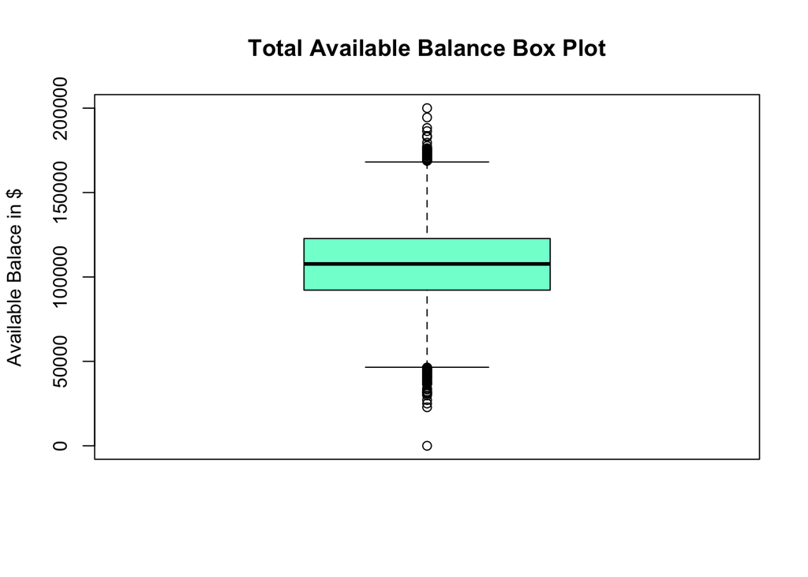

```r
boxplot(loan_data$tot_balance, main="Total Available Balance Box Plot", ylab="Available Balace in $", col="aquamarine", border="black")
```

```r
tot_balance_sum <- summary(loan_data$tot_balance)
tot_balance_sum
```

```
##    Min. 1st Qu.  Median    Mean 3rd Qu.    Max.
##       0   92213  107711  107439  122751  200000
```

Finished!